# Final Project

# **V. Additional Work (Model Selection)**

Based on our EDA, we transformed some variables, but we will want to examine residual plots to determine additional transformations on our explanatory variables before model selection. This is done because model selection may decide an untransformed variable is extraneous, but it may be important if it is transformed.

```r
#model with some transformed variables from EDA
model.full <- lm(logged_viewCount~caption + categoryId + definition + dimension + duration + embeddable + licencedContent + logChannelViewCount + logSubCount + channel_videoCount + logDescription + tags_in_desc + video_title_length + logTagsTitle + logNoTags + channel_title_length + channel_description_length + months_old + channel_months_old + day_uploaded + social_links,data=train)
```

```r
# adding residuals and predicted values to our training data
train <- train %>%
mutate(Residuals = resid(model.full)) %>%
mutate(Predicted = predict(model.full))
```

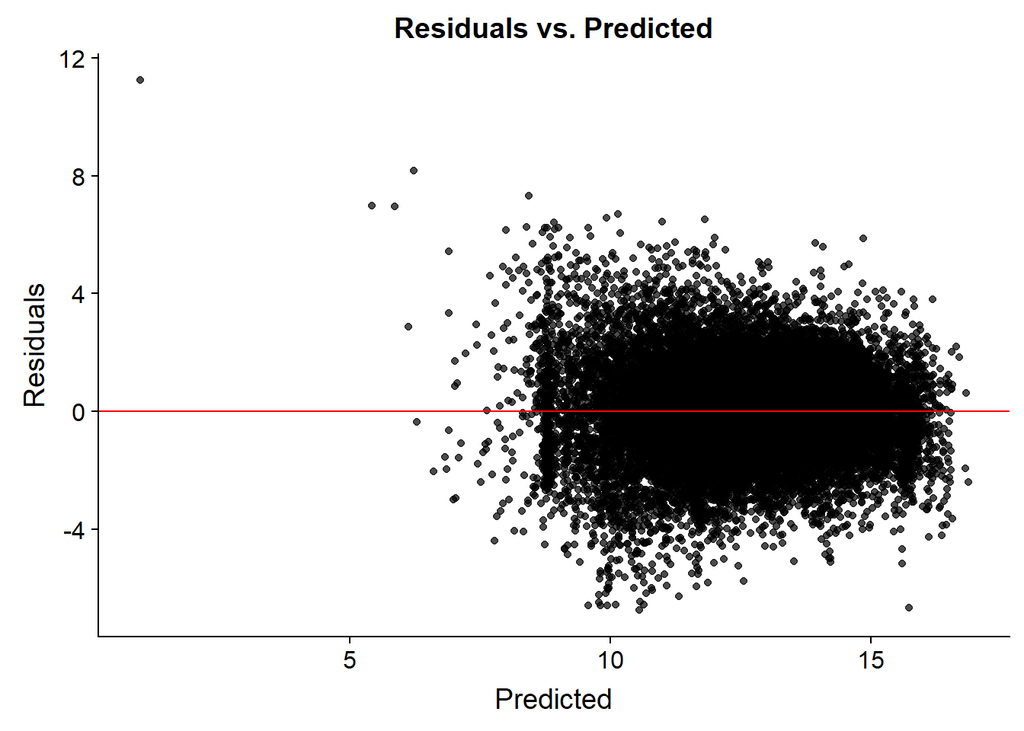

```r
# residuals vs. predicted
p1 <- ggplot(data=train, aes(x=Predicted, y=Residuals)) + geom_point(alpha=0.7) +
  geom_hline(yintercept=0,color="red") +
  labs(title="Residuals vs. Predicted") +
  theme(plot.title=element_text(hjust=0.5))

p1
```

Our residuals vs. predicted plot looks pretty decent- the scatter is pretty random. Next we check the plots against all explanatory variables.

```r
p2 <- ggplot(data=train, aes(x=caption, y=Residuals)) + geom_point(alpha=0.7) +      geom_hline(yintercept=0,color="red") +
  labs(title="Residuals vs. caption") +
  theme(plot.title=element_text(hjust=0.5))

p3 <- ggplot(data=train, aes(x=categoryId, y=Residuals)) + geom_point(alpha=0.7) +
  geom_hline(yintercept=0,color="red") +
  labs(title="Residuals vs. categoryId") +
  theme(plot.title=element_text(hjust=0.5))

p4 <- ggplot(data=train, aes(x=definition, y=Residuals)) + geom_point(alpha=0.7) +
  geom_hline(yintercept=0,color="red") +
  labs(title="Residuals vs. definition") +
  theme(plot.title=element_text(hjust=0.5))

p5 <- ggplot(data=train, aes(x=duration, y=Residuals)) + geom_point(alpha=0.7) +
  geom_hline(yintercept=0,color="red") +
  labs(title="Residuals vs. duration") +
  theme(plot.title=element_text(hjust=0.5))

p6 <- ggplot(data=train, aes(x=embeddable, y=Residuals)) + geom_point(alpha=0.7) +
  geom_hline(yintercept=0,color="red") +
  labs(title="Residuals vs. embeddable") +
  theme(plot.title=element_text(hjust=0.5))

p7 <- ggplot(data=train, aes(x=licencedContent, y=Residuals)) + geom_point(alpha=0.7) +
  geom_hline(yintercept=0,color="red") +
  labs(title="Residuals vs. licencedContent") +
  theme(plot.title=element_text(hjust=0.5))

p8 <- ggplot(data=train, aes(x=logChannelViewCount, y=Residuals)) + geom_point(alpha=0.7) +
  geom_hline(yintercept=0,color="red") +
  labs(title="Residuals vs. logChannelViewCount") +
  theme(plot.title=element_text(hjust=0.5))

p9 <- ggplot(data=train, aes(x=logSubCount, y=Residuals)) + geom_point(alpha=0.7) +
  geom_hline(yintercept=0,color="red") +
  labs(title="Residuals vs. logSubCount") +
  theme(plot.title=element_text(hjust=0.5))

p10 <- ggplot(data=train, aes(x=channel_videoCount, y=Residuals)) + geom_point(alpha=0.7) +
  geom_hline(yintercept=0,color="red") +
  labs(title="Residuals vs. channel_videoCount") +
  theme(plot.title=element_text(hjust=0.5))

p11 <- ggplot(data=train, aes(x=tags_in_desc, y=Residuals)) + geom_point(alpha=0.7) +
  geom_hline(yintercept=0,color="red") +
  labs(title="Residuals vs. tags_in_desc") +
  theme(plot.title=element_text(hjust=0.5))

p12 <- ggplot(data=train, aes(x=video_title_length, y=Residuals)) + geom_point(alpha=0.7) +
  geom_hline(yintercept=0,color="red") +
  labs(title="Residuals vs. video_title_length") +
  theme(plot.title=element_text(hjust=0.5))

p13 <- ggplot(data=train, aes(x=logNoTags, y=Residuals)) + geom_point(alpha=0.7) +
  geom_hline(yintercept=0,color="red") +
  labs(title="Residuals vs. logNoTags") +
  theme(plot.title=element_text(hjust=0.5))

p14 <- ggplot(data=train, aes(x=channel_title_length, y=Residuals)) + geom_point(alpha=0.7) +
  geom_hline(yintercept=0,color="red") +
  labs(title="Residuals vs. channel_title_length") +
  theme(plot.title=element_text(hjust=0.5))

p15 <- ggplot(data=train, aes(x=channel_description_length, y=Residuals)) + geom_point(alpha=0.7) +
  geom_hline(yintercept=0,color="red") +
  labs(title="Residuals vs. channel_description_length") +
  theme(plot.title=element_text(hjust=0.5))

p16 <- ggplot(data=train, aes(x=channel_months_old, y=Residuals)) + geom_point(alpha=0.7) +
  geom_hline(yintercept=0,color="red") +
  labs(title="Residuals vs. channel_months_old") +
  theme(plot.title=element_text(hjust=0.5))

p17 <- ggplot(data=train, aes(x=day_uploaded, y=Residuals)) + geom_point(alpha=0.7) +
  geom_hline(yintercept=0,color="red") +
  labs(title="Residuals vs. day_uploaded") +
  theme(plot.title=element_text(hjust=0.5))

p18 <- ggplot(data=train, aes(x=social_links, y=Residuals)) + geom_point(alpha=0.7) +
  geom_hline(yintercept=0,color="red") +
  labs(title="Residuals vs. social_links") +
  theme(plot.title=element_text(hjust=0.5))
```

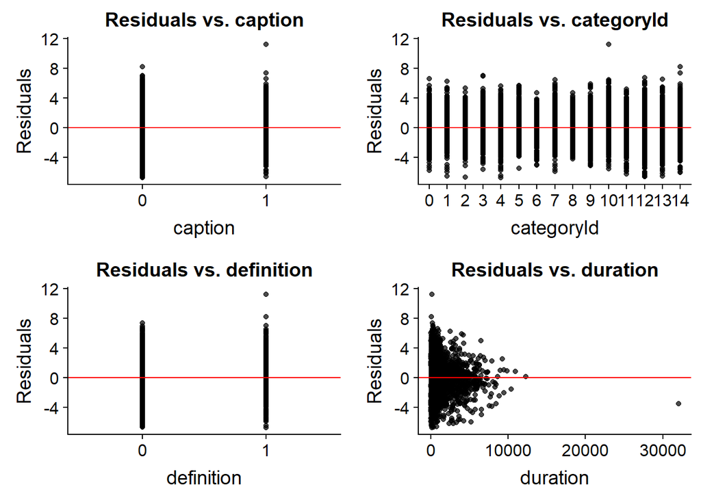

```r
plot_grid(p2, p3, p4, p5)
```

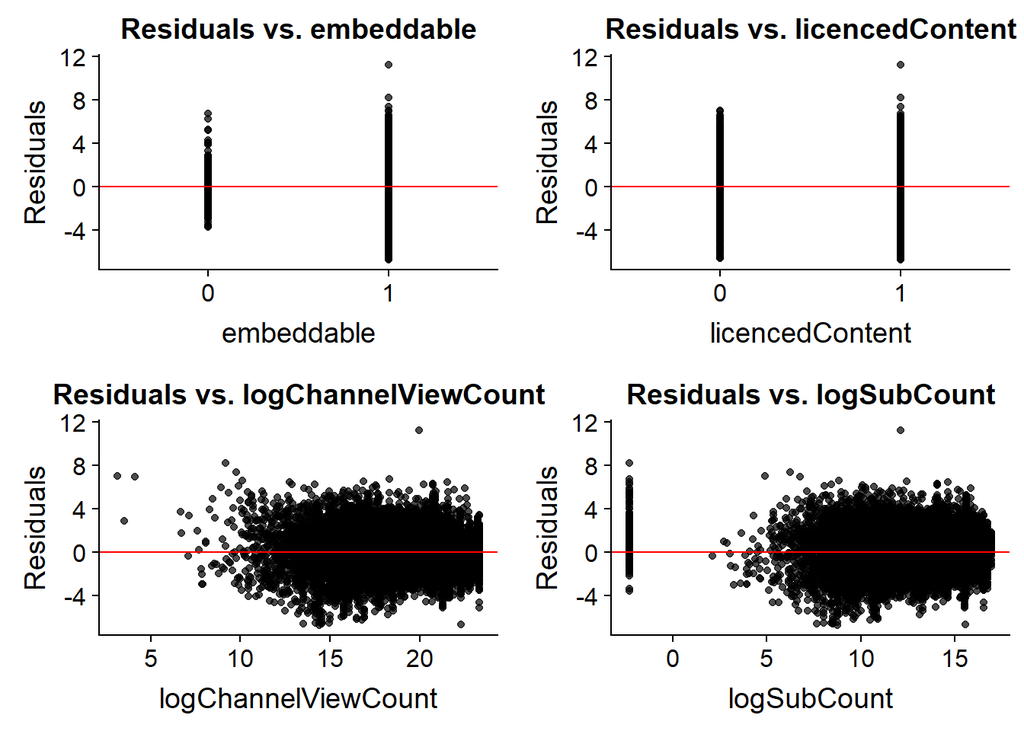

```r
plot_grid(p6, p7, p8, p9)
```

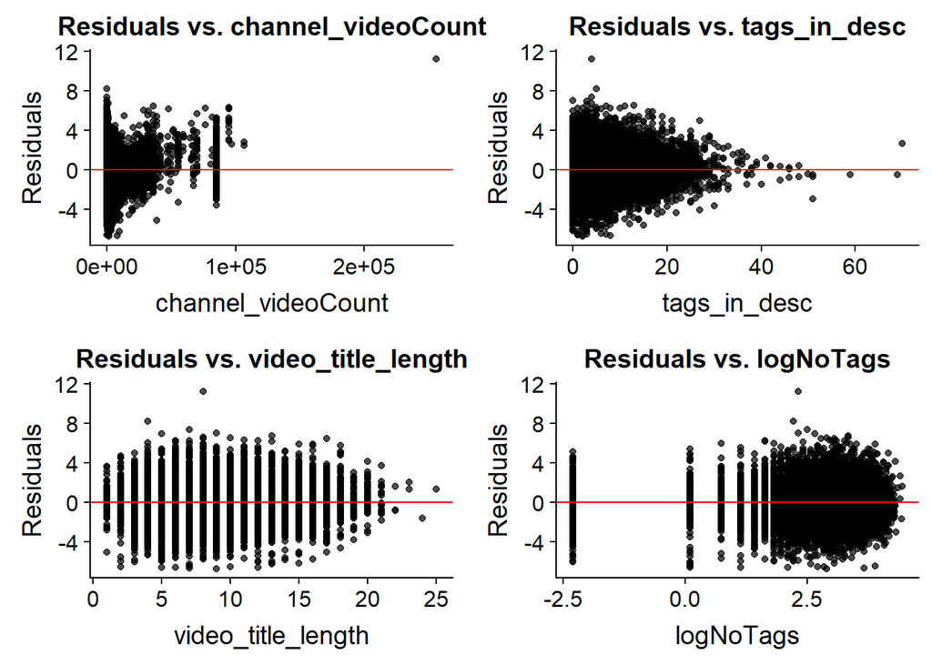

```r
plot_grid(p10, p11, p12, p13)
```

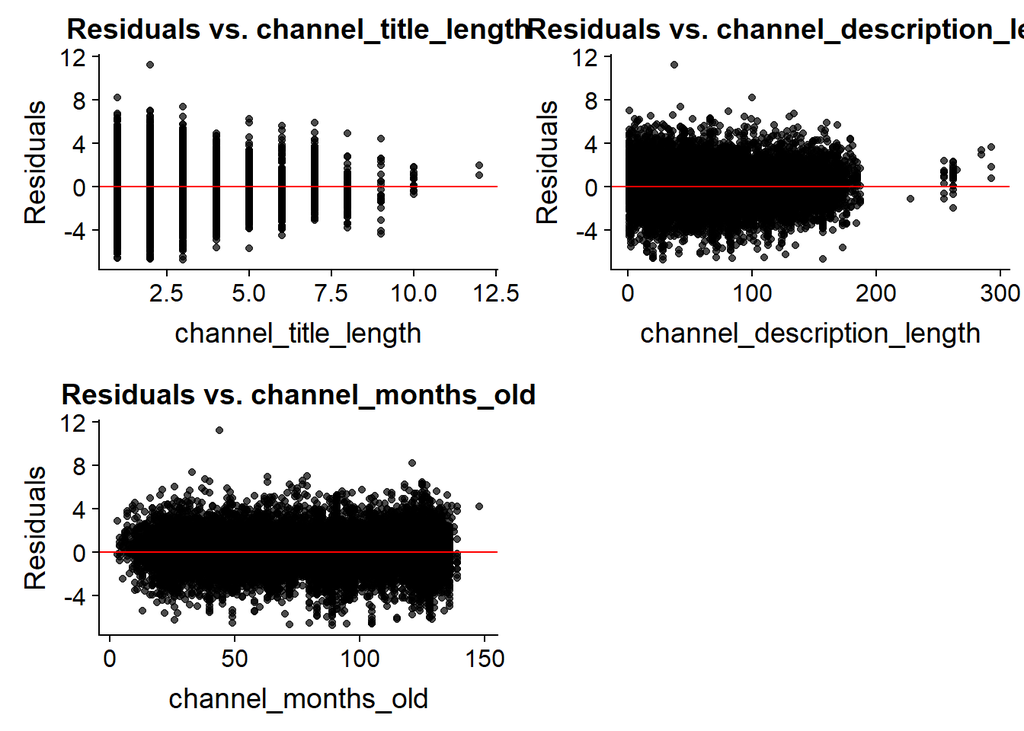

```r
plot_grid(p14,p15,p16)
```

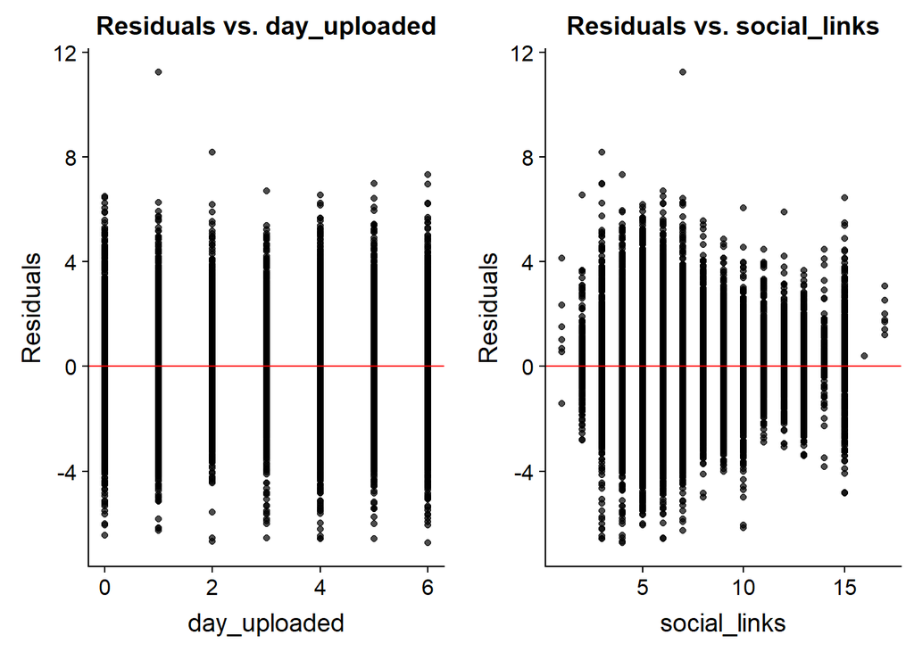

```r
plot_grid(p17,p18)
```

Based on these residual plots, duration, embeddable, channel_videoCount, tags_in_desc, channel_title_length, and channel_description_length may need transformations.

## Potential Transformations:

## a) duration

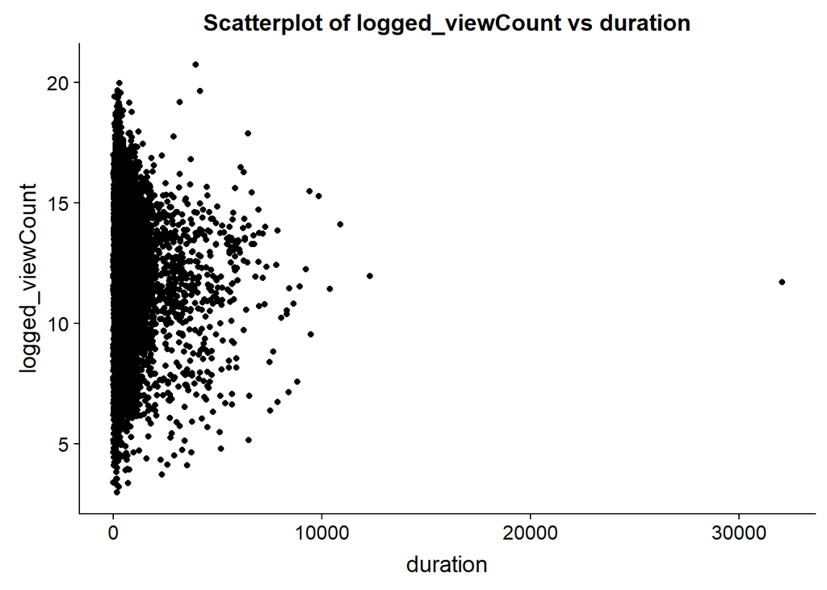

```r
# normal
ggplot(train, aes(x=duration,y=logged_viewCount)) + geom_point()+
  labs(title="Scatterplot of logged_viewCount vs duration") +
  theme(plot.title=element_text(hjust=0.5))
```

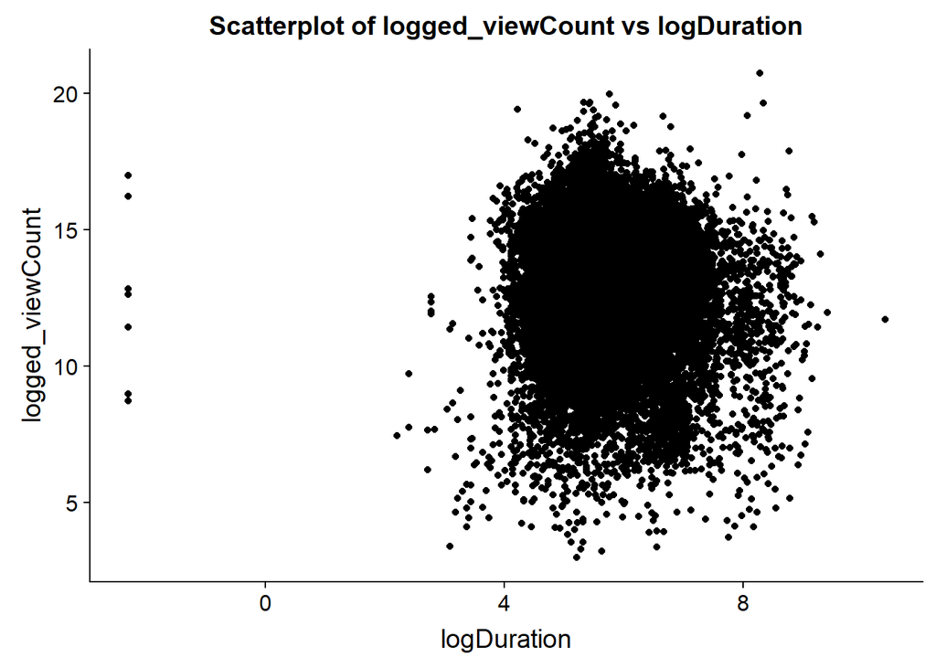

```r
# logged
shift <-.1
train<-train%>%mutate(logDuration = log(duration+shift))
ggplot(train, aes(x=logDuration, y = logged_viewCount)) + geom_point()+
  labs(title="Scatterplot of logged_viewCount vs logDuration") +
  theme(plot.title=element_text(hjust=0.5))
```

It looks like the logged version of the variable produces a much better scatterplot. There is now less of a concern for non constant variance. We will proceed to use the logged version of this variable and add it to the testing data set as well.

```r
# add to testing data
test<-test%>%mutate(logDuration = log(duration+shift))
```

## b) channel_videoCount

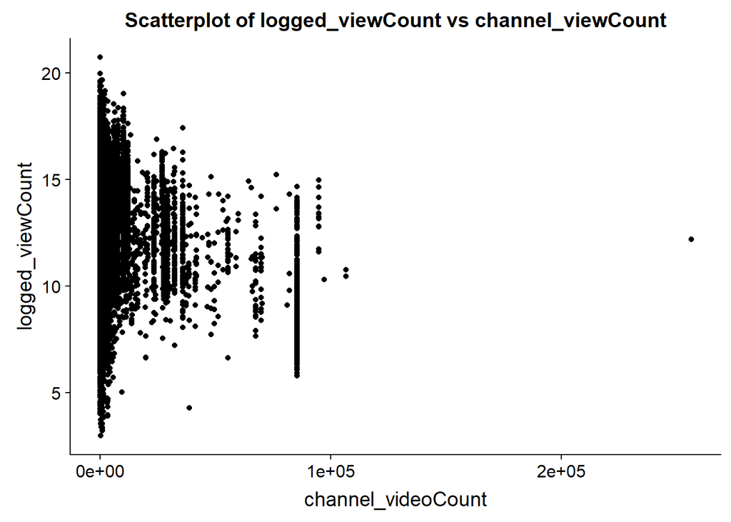

```r
# normal
ggplot(train, aes(x=channel_videoCount,y=logged_viewCount)) + geom_point()+
  labs(title="Scatterplot of logged_viewCount vs channel_viewCount") +
  theme(plot.title=element_text(hjust=0.5))
```

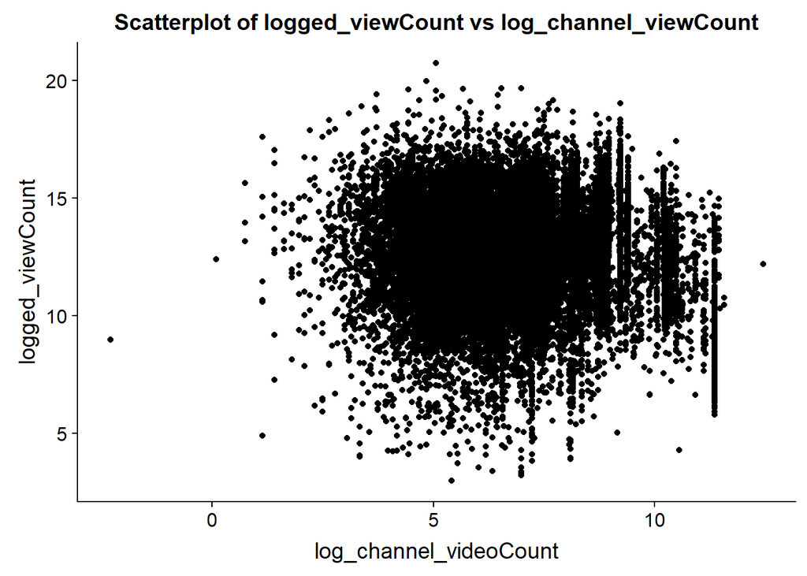

```r
# logged
shift <-.1
train<-train%>%mutate(log_channel_videoCount = log(channel_videoCount+shift))
ggplot(train, aes(x=log_channel_videoCount, y = logged_viewCount)) + geom_point()+
  labs(title="Scatterplot of logged_viewCount vs log_channel_viewCount") +
  theme(plot.title=element_text(hjust=0.5))
```

```r
# add to testing data
test<-test%>%mutate(log_channel_videoCount = log(channel_videoCount+shift))
```

## c) channel_title_length

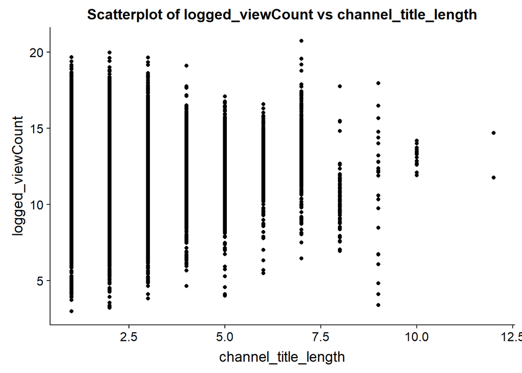

```r
# normal
ggplot(train, aes(x=channel_title_length,y=logged_viewCount)) + geom_point()+
  labs(title="Scatterplot of logged_viewCount vs channel_title_length") +
  theme(plot.title=element_text(hjust=0.5))
```

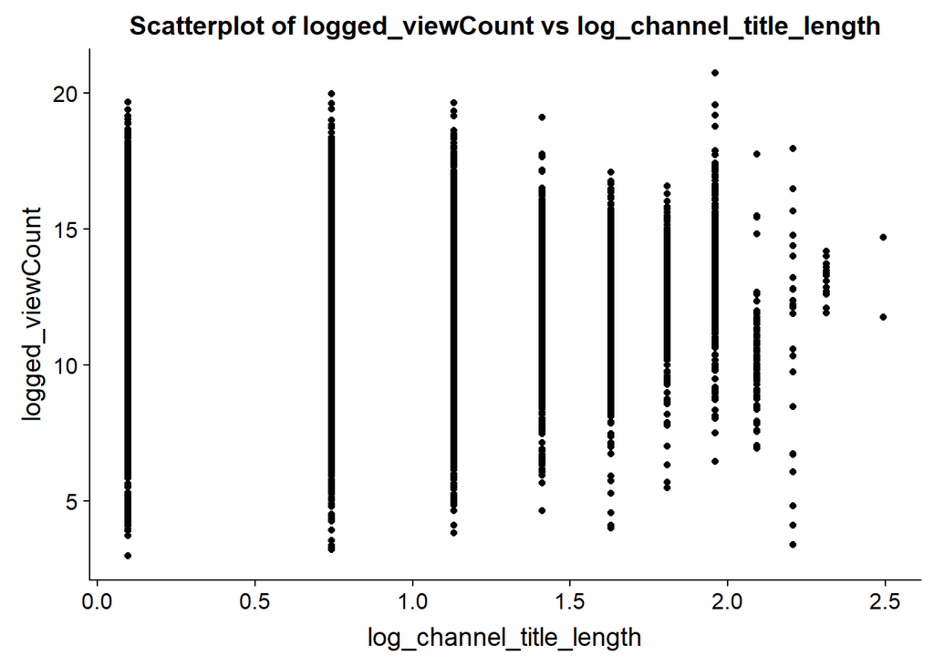

```r
# logged
shift <-.1
train<-train%>%mutate(log_channel_title_length = log(channel_title_length+shift))
ggplot(train, aes(x=log_channel_title_length, y = logged_viewCount)) + geom_point()+
  labs(title="Scatterplot of logged_viewCount vs log_channel_title_length") +
  theme(plot.title=element_text(hjust=0.5))
```

It looks like the logged version of channel_title_length improves the scatter plot. We will proceed with the logged version.

```r
# add to testing data
test<-test%>%mutate(log_channel_title_length = log(channel_title_length+shift))
```

## d) channel_description_length

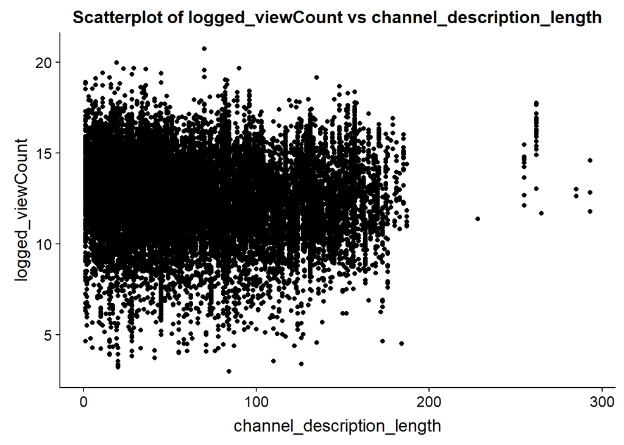

```r
# normal
ggplot(train, aes(x=channel_description_length,y=logged_viewCount)) + geom_point()+
  labs(title="Scatterplot of logged_viewCount vs channel_description_length") +
  theme(plot.title=element_text(hjust=0.5))
```

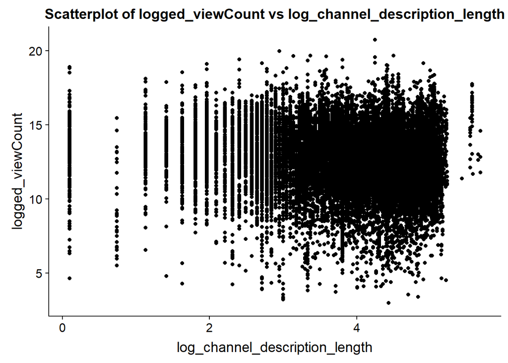

```r
# logged
shift <-.1
train<-train%>%mutate(log_channel_description_length = log(channel_description_length+shift))
ggplot(train, aes(x=log_channel_description_length, y = logged_viewCount)) + geom_point()+
  labs(title="Scatterplot of logged_viewCount vs log_channel_description_length") +
  theme(plot.title=element_text(hjust=0.5))
```

It looks like the log transformation improves the scatterplot of the variable. We will proceed with using the logged version of log_channel_description_length.

```r
# add to testing data
test<-test%>%mutate(log_channel_description_length = log(channel_description_length+shift))
```

We started off with a model containing every variable we didn’t remove. Additionally, we performed our model selection by splitting our sample into testing and training data and selecting on the training data. Then we made a model on variables transformed from EDA to find new variables to transform. Finally, we used stepwise selection to select explanatory variables.

```r
## stepwise model selection
# model will all possible variables
model.full <- lm(logged_viewCount~caption + categoryId + definition + dimension + logDuration + embeddable + licencedContent + logChannelViewCount + logSubCount + log_channel_videoCount + logDescription + logTagsDescrp + video_title_length + logTagsTitle + logNoTags + log_channel_title_length + log_channel_description_length + months_old + channel_months_old + day_uploaded + social_links,data=train)

stepwise <- ols_step_both_aic(model.full)
```

```
## Stepwise Selection Method
## -------------------------
##
## Candidate Terms:
##
## 1 . caption
## 2 . categoryId
## 3 . definition
## 4 . dimension
## 5 . logDuration
## 6 . embeddable
## 7 . licencedContent
## 8 . logChannelViewCount
## 9 . logSubCount
## 10 . log_channel_videoCount
## 11 . logDescription
## 12 . logTagsDescrp
## 13 . video_title_length
## 14 . logTagsTitle
## 15 . logNoTags
## 16 . log_channel_title_length
## 17 . log_channel_description_length
## 18 . months_old
## 19 . channel_months_old
## 20 . day_uploaded
## 21 . social_links
##
##
## Variables Entered/Removed:
##
## - categoryId added
## - logChannelViewCount added
## - log_channel_videoCount added
## - months_old added
## - caption added
## - channel_months_old added
## - logDuration added
## - social_links added
## - licencedContent added
## - logNoTags added
## - log_channel_description_length added
## - logSubCount added
## - log_channel_title_length added
## - video_title_length added
## - embeddable added
## - definition added
##
## No more variables to be added or removed.
```

```r
model.full <- lm(logged_viewCount ~ categoryId + logChannelViewCount + log_channel_videoCount + months_old + caption + channel_months_old + logDuration + social_links + licencedContent + logNoTags + log_channel_description_length + logSubCount + log_channel_title_length + video_title_length + embeddable + definition, data=train)

kable(tidy(model.full))
```

| term | estimate | std.error | statistic | p.value |
| --- | --- | --- | --- | --- |
| (Intercept) | 3.2956545 | 0.1499807 | 21.973862 | 0.0000000 |
| categoryId1 | -0.5874190 | 0.0521836 | -11.256778 | 0.0000000 |
| categoryId2 | 1.1517149 | 0.0583481 | 19.738696 | 0.0000000 |
| categoryId3 | -0.8916962 | 0.0588896 | -15.141817 | 0.0000000 |
| categoryId4 | -0.0830091 | 0.0518882 | -1.599768 | 0.1096633 |
| categoryId5 | -0.7855398 | 0.0529475 | -14.836201 | 0.0000000 |
| categoryId6 | -0.0215471 | 0.0526769 | -0.409042 | 0.6825125 |
| categoryId7 | -0.1301270 | 0.0522663 | -2.489692 | 0.0127921 |
| categoryId8 | -0.1159313 | 0.0487419 | -2.378475 | 0.0173922 |
| categoryId9 | 0.2284095 | 0.0472051 | 4.838663 | 0.0000013 |
| categoryId10 | -0.1775235 | 0.0515827 | -3.441532 | 0.0005794 |
| categoryId11 | -0.2621348 | 0.0507788 | -5.162291 | 0.0000002 |
| categoryId12 | -0.5831247 | 0.0484274 | -12.041226 | 0.0000000 |
| categoryId13 | -0.6900467 | 0.0498380 | -13.845807 | 0.0000000 |
| categoryId14 | -1.2450650 | 0.0579849 | -21.472212 | 0.0000000 |
| logChannelViewCount | 0.7634043 | 0.0091105 | 83.793998 | 0.0000000 |
| log_channel_videoCount | -0.7362540 | 0.0085666 | -85.944588 | 0.0000000 |
| months_old | 0.0085022 | 0.0005534 | 15.363855 | 0.0000000 |
| caption1 | 0.2632273 | 0.0200641 | 13.119351 | 0.0000000 |
| channel_months_old | -0.0031208 | 0.0002985 | -10.455802 | 0.0000000 |
| logDuration | 0.1245573 | 0.0118687 | 10.494625 | 0.0000000 |
| social_links | -0.0292264 | 0.0040556 | -7.206423 | 0.0000000 |
| licencedContent1 | -0.1789094 | 0.0293987 | -6.085616 | 0.0000000 |
| logNoTags | 0.0668272 | 0.0100719 | 6.635037 | 0.0000000 |
| log_channel_description_length | -0.0553353 | 0.0102672 | -5.389531 | 0.0000001 |
| logSubCount | -0.0348568 | 0.0071090 | -4.903192 | 0.0000009 |
| log_channel_title_length | -0.0754652 | 0.0187469 | -4.025469 | 0.0000570 |
| video_title_length | 0.0099168 | 0.0027113 | 3.657504 | 0.0002552 |
| embeddable1 | 0.2486193 | 0.0783393 | 3.173623 | 0.0015074 |
| definition1 | 0.0761626 | 0.0412167 | 1.847861 | 0.0646348 |

```r
model.no.definition <- lm(logged_viewCount ~ categoryId + logChannelViewCount + log_channel_videoCount + months_old + caption + channel_months_old + logDuration + social_links + licencedContent + logNoTags + log_channel_description_length + logSubCount + log_channel_title_length + video_title_length + embeddable , data=train)

model.definition <- lm(logged_viewCount ~ categoryId + logChannelViewCount + log_channel_videoCount + months_old + caption + channel_months_old + logDuration + social_links + licencedContent + logNoTags + log_channel_description_length + logSubCount + log_channel_title_length + video_title_length + embeddable +definition, data=train)

anova(model.no.definition, model.definition)
```

```
## Analysis of Variance Table
##
## Model 1: logged_viewCount ~ categoryId + logChannelViewCount + log_channel_videoCount +
##     months_old + caption + channel_months_old + logDuration +
##     social_links + licencedContent + logNoTags + log_channel_description_length +
##     logSubCount + log_channel_title_length + video_title_length +
##     embeddable
## Model 2: logged_viewCount ~ categoryId + logChannelViewCount + log_channel_videoCount +
##     months_old + caption + channel_months_old + logDuration +
##     social_links + licencedContent + logNoTags + log_channel_description_length +
##     logSubCount + log_channel_title_length + video_title_length +
##     embeddable + definition
##   Res.Df   RSS Df Sum of Sq      F  Pr(>F)
## 1  23968 46159
## 2  23967 46152  1    6.5754 3.4146 0.06463 .
## ---
## Signif. codes:  0 '***' 0.001 '**' 0.01 '*' 0.05 '.' 0.1 ' ' 1
```

Since the p-value is above 0.05, we will not include definition in our model.